# replication_group8

2025-08-24

## Preprocess

```r
# パッケージ読み込み ---------------------------------------------------------------
library(tidyverse)
library(haven)
library(modi)
library(Hmisc)
library(estimatr)
```

# Check data

```r
# データ読み込み -----------------------------------------------------------------
df_china <-
  read_dta("../Autor-Dorn-Hanson-ChinaSyndrome-FileArchive/dta/workfile_china.dta")
```

All variables with the prefix “l_” refer to start-of-period values while variables with the prefix “d_” correspond to 10-year equivalent changes. This file is the basis for all Tables in the paper except Tables 1 and 2.

```r
# what are the variables?
df_china |>
  select(starts_with("d_")) |>
  names() |>
  str()
```

```
##  chr [1:96] "d_tradeusch_pw" "d_tradeotch_pw_lag" "d_popcount" "d_sh_empl" ...
```

```r
# descriptive statistics
df_china |>
  select(d_tradeusce_pw ) |>
  summary()
```

```
##  d_tradeusce_pw
##  Min.   :-6.3367
##  1st Qu.: 0.0840
##  Median : 0.4267
##  Mean   : 0.9014
##  3rd Qu.: 1.2557
##  Max.   :12.5960
```

```r
# データの確認のため
df_china |>
  select(yr, d_tradeusce_pw) |>
  group_by(yr) |>
  summarise(mean = mean(d_tradeusce_pw))
```

```
## # A tibble: 2 × 2
##      yr  mean
##   <dbl> <dbl>
## 1  1990 1.37
## 2  2000 0.431
```

## Replicate App Tab 1&2

```r
# App Table1 panel A
df_china |>
  group_by(yr) |>
  dplyr::summarize(
    w_10 = weighted.quantile(d_tradeusch_pw, timepwt48, prob = 0.10),
    w_25 = weighted.quantile(d_tradeusch_pw, timepwt48, prob = 0.25),
    w_50 = weighted.quantile(d_tradeusch_pw, timepwt48, prob = 0.5),
    w_75 = weighted.quantile(d_tradeusch_pw, timepwt48, prob = 0.75),
    w_90 = weighted.quantile(d_tradeusch_pw, timepwt48, prob = 0.9)
  )
```

```
## # A tibble: 2 × 6
##      yr  w_10  w_25  w_50  w_75  w_90
##   <dbl> <dbl> <dbl> <dbl> <dbl> <dbl>
## 1  1990 0.378 0.623 0.889  1.32  2.05
## 2  2000 1.03  1.60  2.11   3.11  4.30
```

### App Table1 panel B

```r
# App Table1 panel B

# Create a subset data for getting top 40 populated cities in 1990
df_china_top40 <- df_china |>
  select(yr, czone, city, d_tradeusch_pw, l_popcount) |>
  mutate(pop1990 = if_else(yr == 1990, l_popcount, 0)) |>
  arrange(desc(pop1990)) |>
  mutate(
    pop40 = if_else(yr == 1990 & row_number() <= 40, 1, 0)
  ) |>
  group_by(czone) |>
  mutate(top40 = sum(pop40)) |> # copying "1" for data in 2000
  ungroup()


# App Table1 panel B

# left-hand side (1990-2000)
df_china_top40 |>
  filter(yr == 1990 & top40 == 1) |>
  select(city, d_tradeusch_pw) |>
  arrange(desc(d_tradeusch_pw)) |>
  print(n = 40)
```

```
## # A tibble: 40 × 2
##    city               d_tradeusch_pw
##    <chr>                       <dbl>
##  1 San Jose CA                 3.15
##  2 Providence RI               2.59
##  3 Buffalo NY                  2.24
##  4 Boston MA                   1.55
##  5 Portland OR                 1.53
##  6 San Diego CA                1.52
##  7 Newark NJ                   1.32
##  8 Los Angeles CA              1.28
##  9 Bridgeport CT               1.27
## 10 Denver CO                   1.23
## 11 Cincinnati OH               1.22
## 12 Chicago IL                  1.18
```

[output cut: 28 more lines]

```r
# right-hand side (2000-2007)
df_china_top40 |>
  filter(yr == 2000 & top40 == 1) |>
  select(city, d_tradeusch_pw) |>
  arrange(desc(d_tradeusch_pw)) |>
  print(n = 40)
```

```
## # A tibble: 40 × 2
##    city               d_tradeusch_pw
##    <chr>                       <dbl>
##  1 San Jose CA                 7.32
##  2 Providence RI               4.99
##  3 Los Angeles CA              3.59
##  4 San Diego CA                3.08
##  5 Portland OR                 2.96
##  6 Pittsburgh PA               2.95
##  7 Chicago IL                  2.93
##  8 Milwaukee WI                2.93
##  9 Boston MA                   2.79
## 10 Dallas TX                   2.77
## 11 Cleveland OH                2.54
## 12 Bridgeport CT               2.39
```

[output cut: 28 more lines]

# Visualize data

```r
# データ読み込み -----------------------------------------------------------------
df_china_long <-
  read_dta("../Autor-Dorn-Hanson-ChinaSyndrome-FileArchive/dta/workfile_china_long.dta")

# descriptive statistics
df_china_long |>
  summary()
```

```
##      czone          statefip       timepwt48          d_pct_manuf
##  Min.   :  100   Min.   : 1.00   Min.   :5.255e-06   Min.   :-23.4701
##  1st Qu.:12401   1st Qu.:19.00   1st Qu.:1.483e-04   1st Qu.: -4.4682
##  Median :25951   Median :30.00   Median :3.949e-04   Median : -2.1465
##  Mean   :22132   Mean   :30.86   Mean   :1.385e-03   Mean   : -2.5557
##  3rd Qu.:30907   3rd Qu.:46.00   3rd Qu.:1.082e-03   3rd Qu.: -0.3045
##  Max.   :39400   Max.   :56.00   Max.   :5.887e-02   Max.   :  6.5501
##  d_tradeusch_pw      d_tradeotch_pw_lag l_shind_manuf_cbp
##  Min.   : 0.000002   Min.   :-0.1118    Min.   :0.006904
##  1st Qu.: 0.924520   1st Qu.: 0.9113    1st Qu.:0.120067
##  Median : 2.566071   Median : 2.3439    Median :0.213734
##  Mean   : 3.425984   Mean   : 2.9475    Mean   :0.221312
##  3rd Qu.: 4.518994   3rd Qu.: 4.1414    3rd Qu.:0.302650
##  Max.   :49.004984   Max.   :27.9581    Max.   :0.618197
```

## Get residuals

```r
# fit our model for X
x_fit <-
  lm(d_tradeusch_pw ~ l_shind_manuf_cbp,
     data = df_china_long,
     weights = timepwt48)

# save the residuals for X
x_res <- resid(x_fit)
length(x_res)
```

```
## [1] 722
```

```r
# fit our model for Z
z_fit <-
  lm(d_tradeotch_pw_lag ~ l_shind_manuf_cbp,
     data = df_china_long,
     weights = timepwt48)

# save the residuals for Z
z_res <- resid(z_fit)
length(z_res)
```

```
## [1] 722
```

```r
# fit our model for y
y_fit <-
  lm(d_pct_manuf ~ l_shind_manuf_cbp,
     data = df_china_long,
     weights = timepwt48)

# save the residuals for y
y_res <- resid(y_fit)
length(y_res)
```

```
## [1] 722
```

```r
# incorporate residuals into our dataset
df_china_long <- df_china_long |>
  mutate(x_res = x_res,
         z_res = z_res,
         y_res = y_res)
summary(df_china_long)
```

```
##      czone          statefip       timepwt48          d_pct_manuf
##  Min.   :  100   Min.   : 1.00   Min.   :5.255e-06   Min.   :-23.4701
##  1st Qu.:12401   1st Qu.:19.00   1st Qu.:1.483e-04   1st Qu.: -4.4682
##  Median :25951   Median :30.00   Median :3.949e-04   Median : -2.1465
##  Mean   :22132   Mean   :30.86   Mean   :1.385e-03   Mean   : -2.5557
##  3rd Qu.:30907   3rd Qu.:46.00   3rd Qu.:1.082e-03   3rd Qu.: -0.3045
##  Max.   :39400   Max.   :56.00   Max.   :5.887e-02   Max.   :  6.5501
##  d_tradeusch_pw      d_tradeotch_pw_lag l_shind_manuf_cbp      x_res
##  Min.   : 0.000002   Min.   :-0.1118    Min.   :0.006904   Min.   :-7.8203
##  1st Qu.: 0.924520   1st Qu.: 0.9113    1st Qu.:0.120067   1st Qu.:-1.6427
##  Median : 2.566071   Median : 2.3439    Median :0.213734   Median :-0.6129
##  Mean   : 3.425984   Mean   : 2.9475    Mean   :0.221312   Mean   :-0.2939
##  3rd Qu.: 4.518994   3rd Qu.: 4.1414    3rd Qu.:0.302650   3rd Qu.: 0.1701
##  Max.   :49.004984   Max.   :27.9581    Max.   :0.618197   Max.   :44.2095
##      z_res              y_res
##  Min.   :-6.61044   Min.   :-16.58359
##  1st Qu.:-1.61686   1st Qu.: -0.04741
##  Median :-0.95945   Median :  1.45481
##  Mean   :-0.58600   Mean   :  1.65411
##  3rd Qu.: 0.09064   3rd Qu.:  3.06666
##  Max.   :23.63949   Max.   : 10.72712
```

## Run models

### first stage regression

```r
#primitive ver.
lm(d_tradeusch_pw ~ d_tradeotch_pw_lag + l_shind_manuf_cbp,
   data = df_china_long
   ) |>
  summary()
```

```
##
## Call:
## lm(formula = d_tradeusch_pw ~ d_tradeotch_pw_lag + l_shind_manuf_cbp,
##     data = df_china_long)
##
## Residuals:
##      Min       1Q   Median       3Q      Max
## -19.8574  -0.8428  -0.0984   0.4581  29.2662
##
## Coefficients:
##                    Estimate Std. Error t value Pr(>|t|)
## (Intercept)        -0.42964    0.18381  -2.337   0.0197 *
## d_tradeotch_pw_lag  0.93377    0.04093  22.814  < 2e-16 ***
## l_shind_manuf_cbp   4.98546    0.90967   5.481 5.87e-08 ***
## ---
## Signif. codes:  0 '***' 0.001 '**' 0.01 '*' 0.05 '.' 0.1 ' ' 1
##
## Residual standard error: 2.478 on 719 degrees of freedom
## Multiple R-squared:  0.6109, Adjusted R-squared:  0.6098
## F-statistic: 564.5 on 2 and 719 DF,  p-value: < 2.2e-16
```

```r
# weightをかけてみる
df_china_long_w <- df_china_long |>
  mutate(
    d_tradeusch_pw_weighted = d_tradeusch_pw * timepwt48,
    d_tradeotch_pw_lag_weighted = d_tradeotch_pw_lag * timepwt48,
    l_shind_manuf_cbp_weighted = l_shind_manuf_cbp * timepwt48
  )
# turns out this was not necessary...
```

```r
# regression
model <- lm_robust(d_tradeusch_pw ~ d_tradeotch_pw_lag + l_shind_manuf_cbp,
                   data = df_china_long,
                   clusters = statefip,
                   weights = timepwt48,
                   se_type = "stata")

# see the result
model |>
  summary()
```

```
##
## Call:
## lm_robust(formula = d_tradeusch_pw ~ d_tradeotch_pw_lag + l_shind_manuf_cbp,
##     data = df_china_long, weights = timepwt48, clusters = statefip,
##     se_type = "stata")
##
## Weighted, Standard error type:  stata
##
## Coefficients:
##                    Estimate Std. Error t value  Pr(>|t|) CI Lower CI Upper DF
## (Intercept)         -0.7187    0.25048  -2.869 6.144e-03  -1.2226  -0.2148 47
## d_tradeotch_pw_lag   0.8151    0.09177   8.882 1.272e-11   0.6305   0.9997 47
## l_shind_manuf_cbp    7.0419    1.35056   5.214 4.065e-06   4.3249   9.7589 47
##
## Multiple R-squared:  0.6689 ,    Adjusted R-squared:  0.6679
## F-statistic:   125 on 2 and 47 DF,  p-value: < 2.2e-16
```

```r
# another approach
model |>
  broom::tidy()
```

```
##                 term   estimate  std.error statistic      p.value   conf.low
## 1        (Intercept) -0.7187200 0.25047617 -2.869415 6.143648e-03 -1.2226131
## 2 d_tradeotch_pw_lag  0.8150955 0.09176862  8.882073 1.271559e-11  0.6304809
## 3  l_shind_manuf_cbp  7.0419101 1.35056330  5.214054 4.064882e-06  4.3249271
##    conf.high df        outcome
## 1 -0.2148270 47 d_tradeusch_pw
## 2  0.9997102 47 d_tradeusch_pw
## 3  9.7588930 47 d_tradeusch_pw
```

#### Make plot

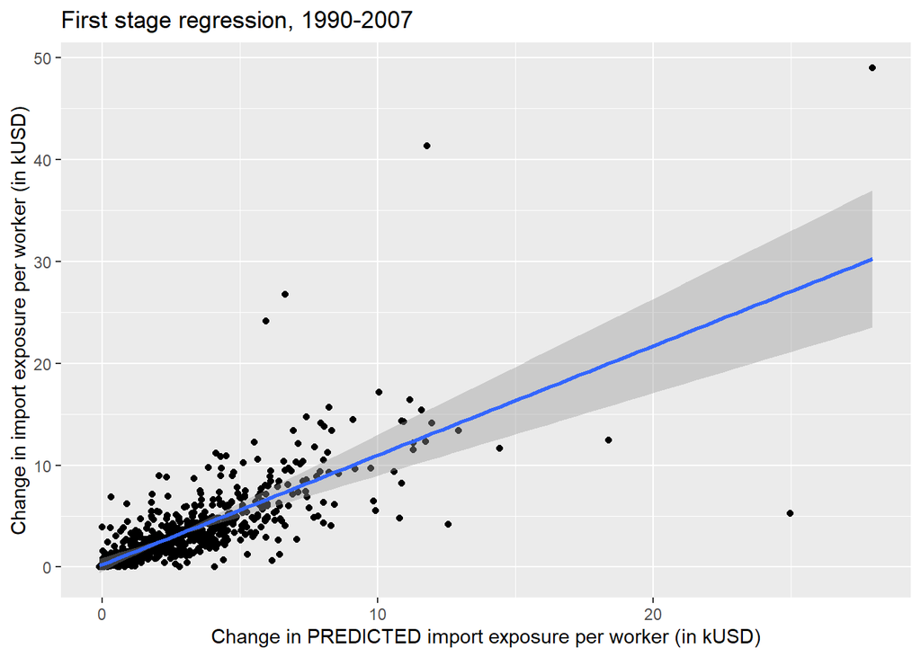

Our first attempt

```r
# scatter plot
df_china_long |>
  ggplot(aes(x = d_tradeotch_pw_lag, y = d_tradeusch_pw)) +
  geom_point() +
  geom_smooth(method = "lm_robust") +
  labs(title = "First stage regression, 1990-2007",
       x = "Change in PREDICTED import exposure per worker (in kUSD)",
       y = "Change in import exposure per worker (in kUSD)")
```

Is this good enough??? Probably not.

```r
# incorporate residuals into our dataset
df_china_long <- df_china_long |>
  mutate(x_res = x_res,
         z_res = z_res)
summary(df_china_long)
```

```
##      czone          statefip       timepwt48          d_pct_manuf
##  Min.   :  100   Min.   : 1.00   Min.   :5.255e-06   Min.   :-23.4701
##  1st Qu.:12401   1st Qu.:19.00   1st Qu.:1.483e-04   1st Qu.: -4.4682
##  Median :25951   Median :30.00   Median :3.949e-04   Median : -2.1465
##  Mean   :22132   Mean   :30.86   Mean   :1.385e-03   Mean   : -2.5557
##  3rd Qu.:30907   3rd Qu.:46.00   3rd Qu.:1.082e-03   3rd Qu.: -0.3045
##  Max.   :39400   Max.   :56.00   Max.   :5.887e-02   Max.   :  6.5501
##  d_tradeusch_pw      d_tradeotch_pw_lag l_shind_manuf_cbp      x_res
##  Min.   : 0.000002   Min.   :-0.1118    Min.   :0.006904   Min.   :-7.8203
##  1st Qu.: 0.924520   1st Qu.: 0.9113    1st Qu.:0.120067   1st Qu.:-1.6427
##  Median : 2.566071   Median : 2.3439    Median :0.213734   Median :-0.6129
##  Mean   : 3.425984   Mean   : 2.9475    Mean   :0.221312   Mean   :-0.2939
##  3rd Qu.: 4.518994   3rd Qu.: 4.1414    3rd Qu.:0.302650   3rd Qu.: 0.1701
##  Max.   :49.004984   Max.   :27.9581    Max.   :0.618197   Max.   :44.2095
##      z_res              y_res
##  Min.   :-6.61044   Min.   :-16.58359
##  1st Qu.:-1.61686   1st Qu.: -0.04741
##  Median :-0.95945   Median :  1.45481
##  Mean   :-0.58600   Mean   :  1.65411
##  3rd Qu.: 0.09064   3rd Qu.:  3.06666
##  Max.   :23.63949   Max.   : 10.72712
```

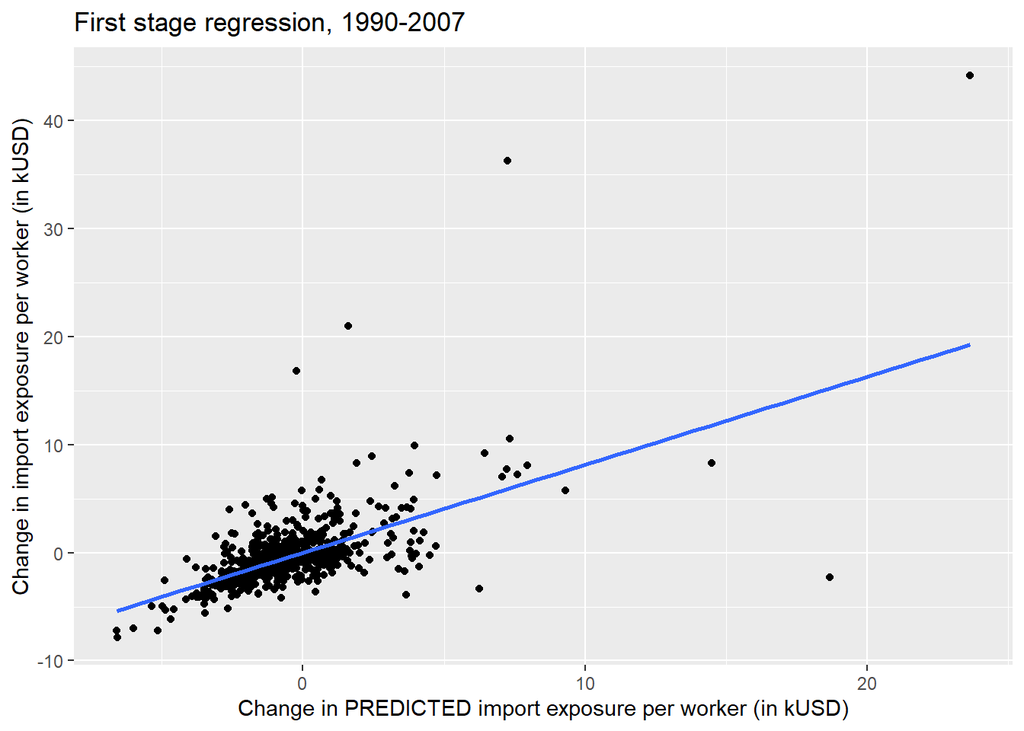

Panel A. 2SLS first stage regression, full sample

```r
# scatter plot (revenge)
df_china_long |>
  ggplot(aes(x = z_res, y = x_res)) +
  geom_point() +
  geom_smooth(method = "lm",
              mapping = aes(weight = timepwt48),
              se = FALSE) +
  labs(title = "First stage regression, 1990-2007",
       x = "Change in PREDICTED import exposure per worker (in kUSD)",
       y = "Change in import exposure per worker (in kUSD)")
```

Now it looks so good!

### second stage regression

```r
# Run regression
lm_robust(d_pct_manuf ~ d_tradeotch_pw_lag + l_shind_manuf_cbp,
                   data = df_china_long,
                   clusters = statefip,
                   weights = timepwt48,
                   se_type = "stata") |>
  summary()
```

```
##
## Call:
## lm_robust(formula = d_pct_manuf ~ d_tradeotch_pw_lag + l_shind_manuf_cbp,
##     data = df_china_long, weights = timepwt48, clusters = statefip,
##     se_type = "stata")
##
## Weighted, Standard error type:  stata
##
## Coefficients:
##                    Estimate Std. Error t value  Pr(>|t|) CI Lower CI Upper DF
## (Intercept)         -0.6255    0.46313  -1.351 1.833e-01  -1.5572   0.3062 47
## d_tradeotch_pw_lag  -0.3398    0.07116  -4.774 1.796e-05  -0.4829  -0.1966 47
## l_shind_manuf_cbp  -10.7709    3.21911  -3.346 1.620e-03 -17.2469  -4.2949 47
##
## Multiple R-squared:  0.3939 ,    Adjusted R-squared:  0.3922
## F-statistic: 39.27 on 2 and 47 DF,  p-value: 9.403e-11
```

#### Make plot

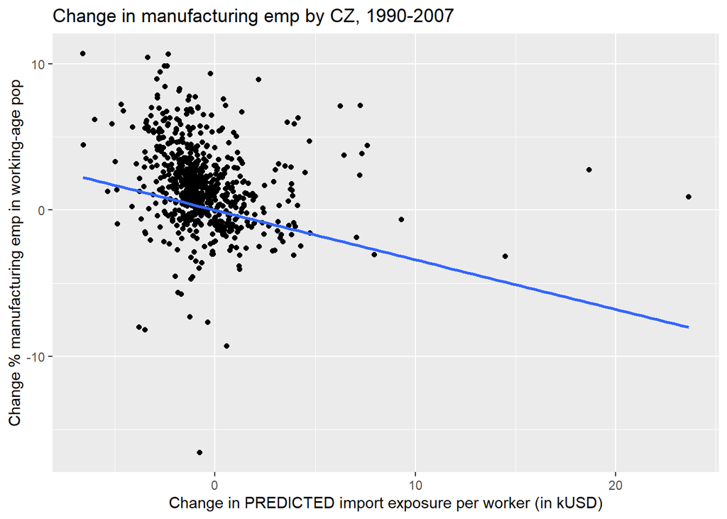

Panel B. OLS reduced form regression, full sample

```r
# scatter plot
df_china_long |>
  ggplot(aes(x = z_res, y = y_res)) +
  geom_point() +
  geom_smooth(method = "lm",
              mapping = aes(weight = timepwt48),
              se = FALSE) +
  labs(title = "Change in manufacturing emp by CZ, 1990-2007",
       x = "Change in PREDICTED import exposure per worker (in kUSD)",
       y = "Change % manufacturing emp in working-age pop")
```

# Replicate the main result (Tab 3)

```r
# データ読み込み -----------------------------------------------------------------
df_china <-
  read_dta("../Autor-Dorn-Hanson-ChinaSyndrome-FileArchive/dta/workfile_china.dta")
```

## IV regression

What’s the original code?

ivregress 2sls d_sh_empl_mfg (d_tradeusch_pw=d_tradeotch_pw_lag) t2 [aw=timepwt48], cluster(statefip) first

```r
# do we have required variables?
df_china |>
  select(d_sh_empl_mfg, d_tradeusch_pw, d_tradeotch_pw_lag, t2)
```

```
## # A tibble: 1,444 × 4
##    d_sh_empl_mfg d_tradeusch_pw d_tradeotch_pw_lag    t2
##            <dbl>          <dbl>              <dbl> <dbl>
##  1        -3.81            5.29              2.28      0
##  2        -4.62            6.62              8.97      1
##  3        -0.681           3.03              2.80      0
##  4        -6.97           10.3               4.48      1
##  5        -2.17            2.06              0.721     0
##  6        -3.78            6.20              4.07      1
##  7        -2.83            1.08              1.45      0
##  8        -3.95            3.11              2.91      1
##  9        -5.04            1.02              1.33      0
## 10        -4.96            2.99              2.53      1
## # ℹ 1,434 more rows
```

### Run 6 models

1. eststo: ivregress 2sls d_sh_empl_mfg (d_tradeusch_pw=d_tradeotch_pw_lag) t2 [aw=timepwt48], cluster(statefip) first
2. eststo: ivregress 2sls d_sh_empl_mfg (d_tradeusch_pw=d_tradeotch_pw_lag) l_shind_manuf_cbp t2 [aw=timepwt48], cluster(statefip) first
3. eststo: ivregress 2sls d_sh_empl_mfg (d_tradeusch_pw=d_tradeotch_pw_lag) l_shind_manuf_cbp reg* t2 [aw=timepwt48], cluster(statefip) first
4. eststo: ivregress 2sls d_sh_empl_mfg (d_tradeusch_pw=d_tradeotch_pw_lag) l_shind_manuf_cbp reg* l_sh_popedu_c l_sh_popfborn l_sh_empl_f t2 [aw=timepwt48], cluster(statefip) first
5. eststo: ivregress 2sls d_sh_empl_mfg (d_tradeusch_pw=d_tradeotch_pw_lag) l_shind_manuf_cbp reg* l_sh_routine33 l_task_outsource t2 [aw=timepwt48], cluster(statefip) first
6. eststo: ivregress 2sls d_sh_empl_mfg (d_tradeusch_pw=d_tradeotch_pw_lag) l_shind_manuf_cbp reg* l_sh_popedu_c l_sh_popfborn l_sh_empl_f l_sh_routine33 l_task_outsource t2 [aw=timepwt48], cluster(statefip) first

Hereby we replicate Table 3. The results are:

```r
# model 1
model1 <-
  iv_robust(
    d_sh_empl_mfg ~ d_tradeusch_pw + t2 | d_tradeotch_pw_lag + t2,
    data = df_china,
    weights = timepwt48,
    clusters = statefip,
    se_type = "stata"
  )
summary(model1)
```

```
##
## Call:
## iv_robust(formula = d_sh_empl_mfg ~ d_tradeusch_pw + t2 | d_tradeotch_pw_lag +
##     t2, data = df_china, weights = timepwt48, clusters = statefip,
##     se_type = "stata")
##
## Weighted, Standard error type:  stata
##
## Coefficients:
##                Estimate Std. Error t value  Pr(>|t|) CI Lower CI Upper DF
## (Intercept)     -1.2178    0.14014  -8.690 2.429e-11  -1.4998  -0.9359 47
## d_tradeusch_pw  -0.7460    0.06881 -10.842 2.208e-14  -0.8845  -0.6076 47
## t2               0.4444    0.32744   1.357 1.812e-01  -0.2143   1.1032 47
##
## Multiple R-squared:  0.06635 ,   Adjusted R-squared:  0.06506
## F-statistic: 75.24 on 2 and 47 DF,  p-value: 2.235e-15
```

```r
# model 2
model2 <-
  iv_robust(
    d_sh_empl_mfg ~ d_tradeusch_pw + l_shind_manuf_cbp + t2 | d_tradeotch_pw_lag + l_shind_manuf_cbp + t2,
    data = df_china,
    weights = timepwt48,
    clusters = statefip,
    se_type = "stata"
  )
summary(model2)
```

```
##
## Call:
## iv_robust(formula = d_sh_empl_mfg ~ d_tradeusch_pw + l_shind_manuf_cbp +
##     t2 | d_tradeotch_pw_lag + l_shind_manuf_cbp + t2, data = df_china,
##     weights = timepwt48, clusters = statefip, se_type = "stata")
##
## Weighted, Standard error type:  stata
##
## Coefficients:
##                   Estimate Std. Error t value  Pr(>|t|) CI Lower  CI Upper DF
## (Intercept)       -0.63824    0.34274 -1.8622 6.884e-02 -1.32774  0.051270 47
## d_tradeusch_pw    -0.61044    0.09513 -6.4172 6.272e-08 -0.80180 -0.419068 47
## l_shind_manuf_cbp -0.03548    0.02205 -1.6090 1.143e-01 -0.07984  0.008881 47
## t2                 0.08461    0.37138  0.2278 8.208e-01 -0.66250  0.831726 47
##
## Multiple R-squared:  0.1567 ,    Adjusted R-squared:  0.1549
## F-statistic:  61.9 on 3 and 47 DF,  p-value: 2.361e-16
```

```r
# model 3
model3 <-
  iv_robust(
    d_sh_empl_mfg ~ d_tradeusch_pw + l_shind_manuf_cbp + reg_midatl + reg_encen + reg_wncen + reg_satl + reg_escen + reg_wscen + reg_mount + reg_pacif + t2 |
    d_tradeotch_pw_lag + l_shind_manuf_cbp + reg_midatl + reg_encen + reg_wncen + reg_satl + reg_escen + reg_wscen + reg_mount + reg_pacif + t2,
    data = df_china,
    weights = timepwt48,
    clusters = statefip,
    se_type = "stata"
  )
summary(model3)
```

```
##
## Call:
## iv_robust(formula = d_sh_empl_mfg ~ d_tradeusch_pw + l_shind_manuf_cbp +
##     reg_midatl + reg_encen + reg_wncen + reg_satl + reg_escen +
##     reg_wscen + reg_mount + reg_pacif + t2 | d_tradeotch_pw_lag +
##     l_shind_manuf_cbp + reg_midatl + reg_encen + reg_wncen +
##     reg_satl + reg_escen + reg_wscen + reg_mount + reg_pacif +
##
## Weighted, Standard error type:  stata
##
## Coefficients:
##                   Estimate Std. Error t value  Pr(>|t|) CI Lower CI Upper DF
## (Intercept)       -0.97518    0.35372 -2.7569 8.282e-03 -1.68678  -0.2636 47
## d_tradeusch_pw    -0.53764    0.09222 -5.8300 4.863e-07 -0.72316  -0.3521 47
## l_shind_manuf_cbp -0.05215    0.02035 -2.5623 1.366e-02 -0.09309  -0.0112 47
## reg_midatl         0.18160    0.20205  0.8988 3.733e-01 -0.22487   0.5881 47
## reg_encen          0.88862    0.27065  3.2833 1.941e-03  0.34414   1.4331 47
## reg_wncen          1.69211    0.46844  3.6122 7.362e-04  0.74972   2.6345 47
## reg_satl          -0.12356    0.27170 -0.4548 6.514e-01 -0.67015   0.4230 47
## reg_escen          1.09423    0.27866  3.9267 2.804e-04  0.53363   1.6548 47
## reg_wscen          1.13359    0.16480  6.8784 1.250e-08  0.80205   1.4651 47
## reg_mount          0.75863    0.26389  2.8748 6.056e-03  0.22774   1.2895 47
## reg_pacif          0.59055    0.15107  3.9091 2.962e-04  0.28663   0.8945 47
## t2                -0.09627    0.37251 -0.2584 7.972e-01 -0.84567   0.6531 47
##
## Multiple R-squared:  0.2817 ,    Adjusted R-squared:  0.2762
## F-statistic: 41.49 on 11 and 47 DF,  p-value: < 2.2e-16
```

```r
# model 4
model4 <-
  iv_robust(
    d_sh_empl_mfg ~ d_tradeusch_pw + l_shind_manuf_cbp + reg_midatl + reg_encen + reg_wncen + reg_satl + reg_escen + reg_wscen + reg_mount + reg_pacif + l_sh_popedu_c + l_sh_popfborn + l_sh_empl_f + t2 |
    d_tradeotch_pw_lag + l_shind_manuf_cbp + reg_midatl + reg_encen + reg_wncen + reg_satl + reg_escen + reg_wscen + reg_mount + reg_pacif + l_sh_popedu_c + l_sh_popfborn + l_sh_empl_f + t2,
    data = df_china,
    weights = timepwt48,
    clusters = statefip,
    se_type = "stata"
  )
summary(model4)
```

```
##
## Call:
## iv_robust(formula = d_sh_empl_mfg ~ d_tradeusch_pw + l_shind_manuf_cbp +
##     reg_midatl + reg_encen + reg_wncen + reg_satl + reg_escen +
##     reg_wscen + reg_mount + reg_pacif + l_sh_popedu_c + l_sh_popfborn +
##     l_sh_empl_f + t2 | d_tradeotch_pw_lag + l_shind_manuf_cbp +
##     reg_midatl + reg_encen + reg_wncen + reg_satl + reg_escen +
##
## Weighted, Standard error type:  stata
##
## Coefficients:
##                    Estimate Std. Error t value  Pr(>|t|) CI Lower  CI Upper DF
## (Intercept)        3.407018   1.181081  2.8847 5.897e-03  1.03099  5.783047 47
## d_tradeusch_pw    -0.507971   0.082422 -6.1630 1.524e-07 -0.67378 -0.342159 47
## l_shind_manuf_cbp -0.061327   0.017230 -3.5594 8.628e-04 -0.09599 -0.026665 47
## reg_midatl        -0.159266   0.198726 -0.8014 4.269e-01 -0.55905  0.240519 47
## reg_encen          0.662912   0.304970  2.1737 3.480e-02  0.04939  1.276432 47
## reg_wncen          1.681112   0.538038  3.1245 3.049e-03  0.59872  2.763505 47
## reg_satl          -0.437244   0.290169 -1.5069 1.385e-01 -1.02099  0.146502 47
## reg_escen          0.451204   0.301457  1.4967 1.411e-01 -0.15525  1.057658 47
## reg_wscen          0.536811   0.221788  2.4204 1.942e-02  0.09063  0.982990 47
## reg_mount          0.448619   0.288208  1.5566 1.263e-01 -0.13118  1.028419 47
## reg_pacif          0.273869   0.214625  1.2760 2.082e-01 -0.15790  0.705638 47
## l_sh_popedu_c     -0.008222   0.016720 -0.4918 6.252e-01 -0.04186  0.025414 47
## l_sh_popfborn     -0.007106   0.007965 -0.8921 3.769e-01 -0.02313  0.008918 47
## l_sh_empl_f       -0.054137   0.025169 -2.1510 3.665e-02 -0.10477 -0.003504 47
## t2                -0.062379   0.319929 -0.1950 8.463e-01 -0.70599  0.581235 47
##
## Multiple R-squared:  0.321 , Adjusted R-squared:  0.3143
## F-statistic: 34.92 on 14 and 47 DF,  p-value: < 2.2e-16
```

```r
# model 5
model5 <-
  iv_robust(
    d_sh_empl_mfg ~ d_tradeusch_pw + l_shind_manuf_cbp + reg_midatl + reg_encen + reg_wncen + reg_satl + reg_escen + reg_wscen + reg_mount + reg_pacif + l_sh_routine33  + l_task_outsource + t2 |
    d_tradeotch_pw_lag + l_shind_manuf_cbp + reg_midatl + reg_encen + reg_wncen + reg_satl + reg_escen + reg_wscen + reg_mount + reg_pacif + l_sh_routine33  + l_task_outsource + t2,
    data = df_china,
    weights = timepwt48,
    clusters = statefip,
    se_type = "stata"
  )
summary(model5)
```

```
##
## Call:
## iv_robust(formula = d_sh_empl_mfg ~ d_tradeusch_pw + l_shind_manuf_cbp +
##     reg_midatl + reg_encen + reg_wncen + reg_satl + reg_escen +
##     reg_wscen + reg_mount + reg_pacif + l_sh_routine33 + l_task_outsource +
##     t2 | d_tradeotch_pw_lag + l_shind_manuf_cbp + reg_midatl +
##     reg_encen + reg_wncen + reg_satl + reg_escen + reg_wscen +
##
## Weighted, Standard error type:  stata
##
## Coefficients:
##                   Estimate Std. Error t value  Pr(>|t|) CI Lower CI Upper DF
## (Intercept)         6.5733    2.13182   3.083 3.421e-03  2.28461 10.86194 47
## d_tradeusch_pw     -0.5625    0.09772  -5.756 6.290e-07 -0.75905 -0.36588 47
## l_shind_manuf_cbp  -0.0563    0.01668  -3.376 1.486e-03 -0.08985 -0.02275 47
## reg_midatl          0.4009    0.17092   2.345 2.328e-02  0.05703  0.74472 47
## reg_encen           1.1839    0.26905   4.400 6.176e-05  0.64265  1.72516 47
## reg_wncen           1.4794    0.40445   3.658 6.415e-04  0.66573  2.29301 47
## reg_satl           -0.2940    0.25679  -1.145 2.580e-01 -0.81062  0.22258 47
## reg_escen           0.9320    0.23317   3.997 2.248e-04  0.46295  1.40109 47
## reg_wscen           0.7965    0.15648   5.090 6.193e-06  0.48173  1.11131 47
## reg_mount           0.3979    0.22619   1.759 8.504e-02 -0.05710  0.85295 47
## reg_pacif           0.4803    0.17679   2.717 9.204e-03  0.12460  0.83591 47
## l_sh_routine33     -0.2301    0.06353  -3.622 7.140e-04 -0.35794 -0.10232 47
## l_task_outsource    0.2440    0.25579   0.954 3.450e-01 -0.27056  0.75859 47
## t2                 -0.1186    0.36930  -0.321 7.496e-01 -0.86149  0.62439 47
##
## Multiple R-squared:  0.3434 ,    Adjusted R-squared:  0.3374
## F-statistic: 42.18 on 13 and 47 DF,  p-value: < 2.2e-16
```

```r
# model 6
model6 <-
  iv_robust(
    d_sh_empl_mfg ~ d_tradeusch_pw + l_shind_manuf_cbp + reg_midatl + reg_encen + reg_wncen + reg_satl + reg_escen + reg_wscen + reg_mount + reg_pacif + l_sh_popedu_c + l_sh_popfborn + l_sh_empl_f + l_sh_routine33 + l_task_outsource + t2 |
    d_tradeotch_pw_lag + l_shind_manuf_cbp + reg_midatl + reg_encen + reg_wncen + reg_satl + reg_escen + reg_wscen + reg_mount + reg_pacif + l_sh_popedu_c + l_sh_popfborn + l_sh_empl_f + l_sh_routine33  + l_task_outsource + t2,
    data = df_china,
    weights = timepwt48,
    clusters = statefip,
    se_type = "stata"
  )
summary(model6)
```

```
##
## Call:
## iv_robust(formula = d_sh_empl_mfg ~ d_tradeusch_pw + l_shind_manuf_cbp +
##     reg_midatl + reg_encen + reg_wncen + reg_satl + reg_escen +
##     reg_wscen + reg_mount + reg_pacif + l_sh_popedu_c + l_sh_popfborn +
##     l_sh_empl_f + l_sh_routine33 + l_task_outsource + t2 | d_tradeotch_pw_lag +
##     l_shind_manuf_cbp + reg_midatl + reg_encen + reg_wncen +
##
## Weighted, Standard error type:  stata
##
## Coefficients:
##                   Estimate Std. Error t value  Pr(>|t|)  CI Lower CI Upper DF
## (Intercept)        6.27851    1.96871  3.1892 2.541e-03  2.317981 10.23905 47
## d_tradeusch_pw    -0.59636    0.10038 -5.9412 3.303e-07 -0.798293 -0.39443 47
## l_shind_manuf_cbp -0.04022    0.01336 -3.0115 4.175e-03 -0.067087 -0.01335 47
## reg_midatl         0.31295    0.28575  1.0952 2.790e-01 -0.261900  0.88780 47
## reg_encen          1.26067    0.34251  3.6806 5.985e-04  0.571620  1.94972 47
## reg_wncen          1.62356    0.37820  4.2929 8.752e-05  0.862726  2.38439 47
## reg_satl          -0.28822    0.23745 -1.2138 2.309e-01 -0.765903  0.18947 47
## reg_escen          1.07623    0.34012  3.1643 2.726e-03  0.392002  1.76047 47
## reg_wscen          0.73164    0.23513  3.1117 3.161e-03  0.258625  1.20465 47
## reg_mount          0.40210    0.26148  1.5378 1.308e-01 -0.123933  0.92814 47
## reg_pacif          0.02683    0.19421  0.1381 8.907e-01 -0.363878  0.41754 47
## l_sh_popedu_c      0.01314    0.01239  1.0602 2.945e-01 -0.011792  0.03807 47
## l_sh_popfborn      0.03038    0.01102  2.7573 8.274e-03  0.008214  0.05254 47
## l_sh_empl_f       -0.00586    0.02487 -0.2357 8.147e-01 -0.055883  0.04416 47
## l_sh_routine33    -0.24489    0.06478 -3.7802 4.414e-04 -0.375214 -0.11457 47
## l_task_outsource  -0.05903    0.24082 -0.2451 8.074e-01 -0.543500  0.42544 47
## t2                -0.24242    0.40707 -0.5955 5.543e-01 -1.061349  0.57650 47
##
## Multiple R-squared:  0.3429 ,    Adjusted R-squared:  0.3355
## F-statistic: 42.53 on 16 and 47 DF,  p-value: < 2.2e-16
```